# Bonus Métodos específicos generación variables aleatorias

Simulación Digital - Grupo H1

2170688 - Brayan Rodolfo Barajas Ochoa 217206 - Kevin Javier Lozano Galvis 2161342 - Carlos Alberto Palencia Pombo

#Solución

##1) Box-Muller:

```r
v1=numeric();v2=numeric();s=numeric();x=numeric();y=numeric()
i=1
while (i<=1000){
  #Se genera v1 y v2, que son variables aleatorias uniformes entre (-1,1)
  v1[i] <- (2*runif(1))-1
  v2[i] <- (2*runif(1))-1
  #Se calcula R^2=s, que a su vez se utiliza posteriormente como variable
  #aleatoria uniforme entre (0,1)
  s[i] <- v1[i]^2 + v2[i]^2
  #Si se encuentra dentro del circulo unitario, se realiza el calculo
  if (s[i] <= 1){
    x[i]<- v1[i]*sqrt((-2*log(s[i]))/s[i])
    y[i]<- v2[i]*sqrt((-2*log(s[i]))/s[i])
    i=i+1
  }
}
```

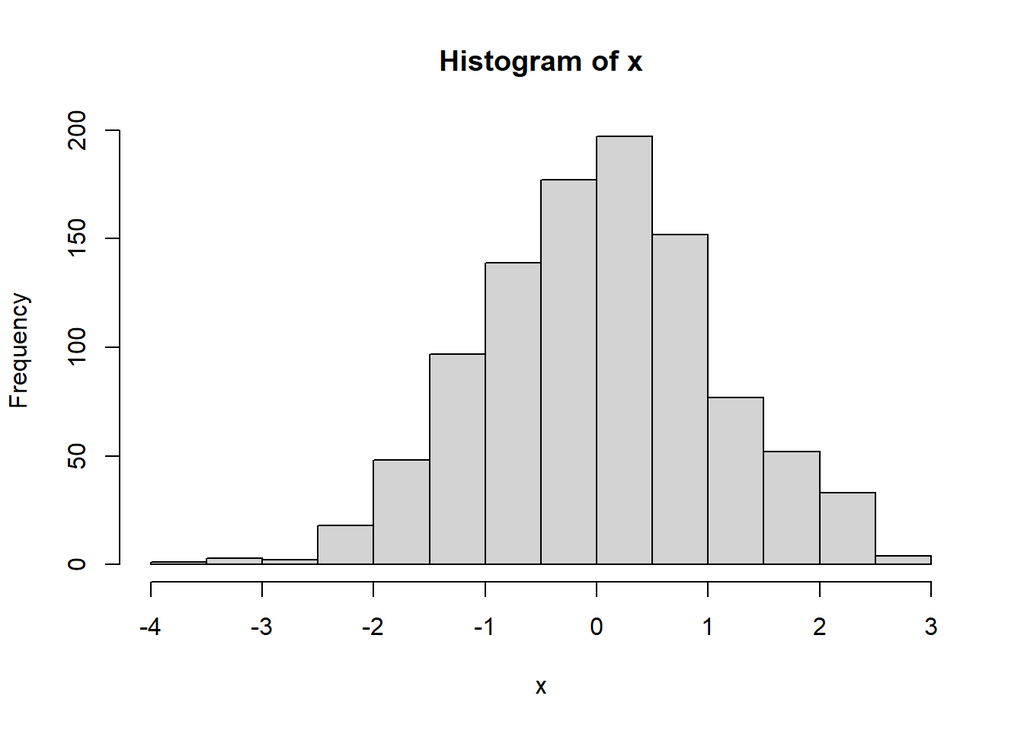

```r
hist(x)
```

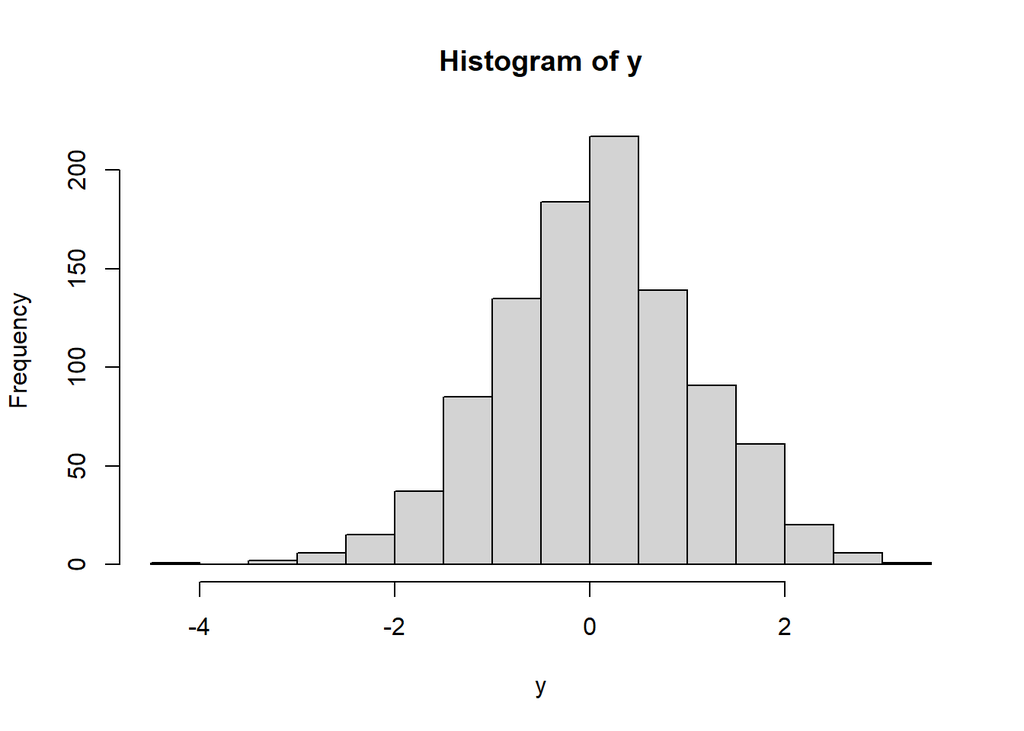

```r
hist(y)
```

```r
ks.test(x,"pnorm")
```

```
##
##  One-sample Kolmogorov-Smirnov test
##
## data:  x
## D = 0.023654, p-value = 0.6305
## alternative hypothesis: two-sided
```

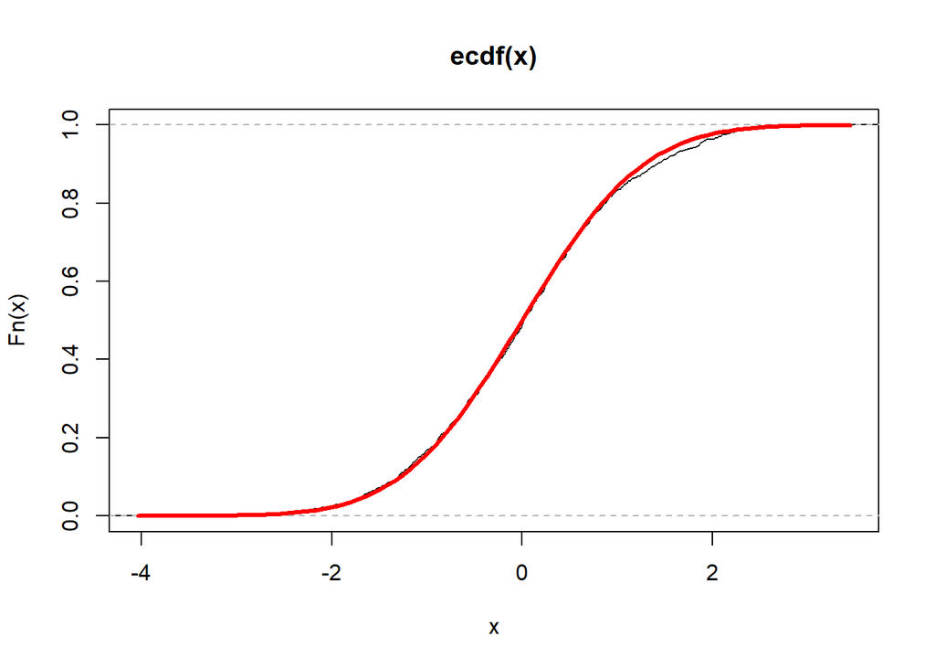

```r
plot(ecdf(x))
curve(pnorm(x),add=TRUE,col="red",lwd=3)
```

```r
ks.test(y,"pnorm")
```

```
##
##  One-sample Kolmogorov-Smirnov test
##
## data:  y
## D = 0.039807, p-value = 0.08407
## alternative hypothesis: two-sided
```

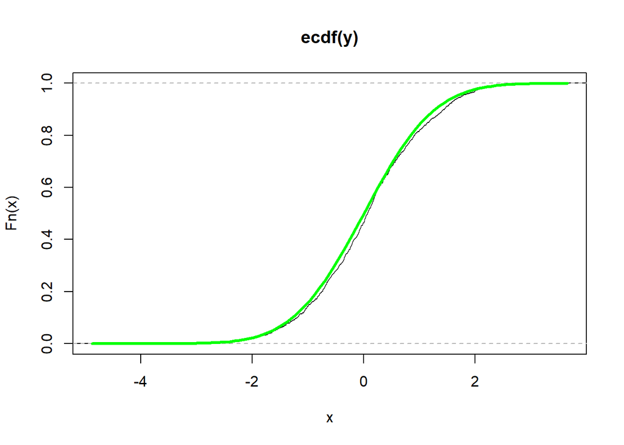

```r
plot(ecdf(y))
curve(pnorm(x),add=TRUE,col="green",lwd=3)
```

```r
#Contraste de correlación
cor.test(x,y)
```

```
##
##  Pearson's product-moment correlation
##
## data:  x and y
## t = -1.4809, df = 998, p-value = 0.139
## alternative hypothesis: true correlation is not equal to 0
## 95 percent confidence interval:
##  -0.10850260  0.01521277
## sample estimates:
##         cor
## -0.04682447
```

Al comparar las diferentes implementaciones del Método de Box Muller, se observa que en la primera implementación realizada en clase se utilizan funciones trigonométricas, en particular el coseno y seno para poder hallar “X” y “Y”. Ahora bien, al implementarlo de la otra manera, las funciones trigonométricas se pueden reemplazar utilizando pares de números aleatorios que se encuentran dentro del círculo unitario para obtener el valor del seno y del coseno. Esto en términos computacionales reducen el costo de la implementación ya que se hace más factible realizar multiplicaciones y divisiones que hallar las funciones trigonométricas.

##2) Poisson no homogéneo

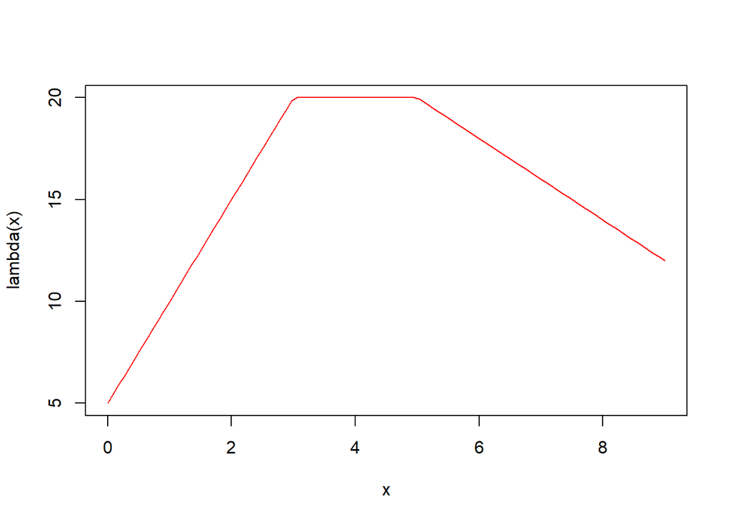

```r
lambda<-function(x)(5+5*x)*I(x<=3)+20*I(x>=3&x<=5)+(20-2*(x-5))*I(x>=5&x<=9)
curve(lambda(x),xlim=c(0,9),ylab="lambda(x)",col="red")
```

```
## [1] "S"
##   [1] 0.05656951 0.14618444 0.19541550 0.19642254 0.29678879 0.59492436
##   [7] 0.62642745 0.64378064 0.81487463 0.93391007 0.94896827 0.99134004
##  [13] 1.00962071 1.02961081 1.22292863 1.22928493 1.32337661 1.34165857
##  [19] 1.51437230 1.60893633 1.72740754 1.77340694 1.84171211 1.86315337
##  [25] 1.89799443 1.95290820 1.95425926 1.95742340 2.05786727 2.14748129
##  [31] 2.15259268 2.16892346 2.18801268 2.22058682 2.24137667 2.44107881
##  [37] 2.44775918 2.54834296 2.61578592 2.63356943 2.66017942 2.71775897
##  [43] 2.81630634 2.89477285 2.95767230 3.05605085 3.21938698 3.35708350
##  [49] 3.43210996 3.44157873 3.46826322 3.47365266 3.55106782 3.61833059
##  [55] 3.64884977 3.67918299 3.70005495 3.70562247 3.74865089 3.81817569
##  [61] 3.85225789 3.92473102 3.97239711 3.97458995 4.11787211 4.15140096
##  [67] 4.26368587 4.26864592 4.31134484 4.33551949 4.35227532 4.40114745
##  [73] 4.46635040 4.66509921 4.67995946 4.79389919 4.87565697 4.93113634
##  [79] 4.93566491 5.07850766 5.14597837 5.16412924 5.16566187 5.19157562
##  [85] 5.19705181 5.33220641 5.36450858 5.38130156 5.39874523 5.43648130
##  [91] 5.44998742 5.49047739 5.50664006 5.52679595 5.68157295 5.77426344
##  [97] 5.88060673 5.90684111 5.93876413 6.00145688 6.08740851 6.12151676
## [103] 6.13221043 6.14607792 6.28207423 6.29930115 6.38689706 6.39631881
## [109] 6.52847477 6.60037513 6.67249088 6.73808963 6.77786586 6.85608157
## [115] 6.90315883 6.92416158 7.04933695 7.13086352 7.19964585 7.31790969
## [121] 7.33489772 7.37390433 7.43833304 7.44405654 7.46513390 7.50978747
## [127] 7.51050727 7.64014407 7.75086673 7.88770763 7.99619789 8.00822652
## [133] 8.05547891 8.08082755 8.09346570 8.11219079 8.12070668 8.20243623
## [139] 8.29649240 8.53549283 8.55882368 8.62412529 8.62593032 8.65280656
## [145] 8.83368814 8.87920252
## [1] "tasa de aceptación"
## [1] 0.918239
## [1] "número medio de realizaciones"
## [1] 1.089041
```

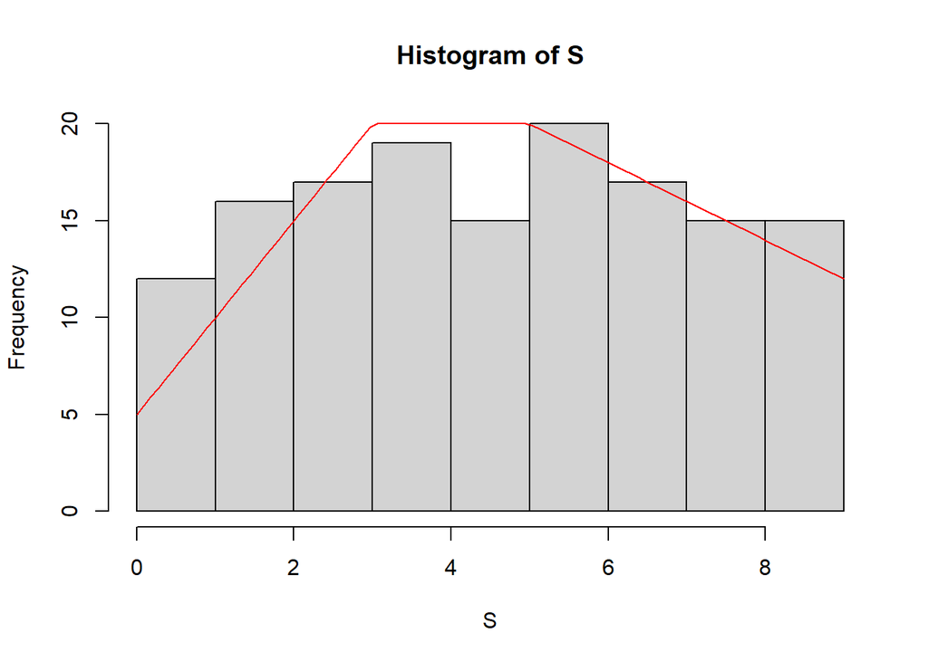

```r
#Esta funcion hace el calculo con intervalos predefinidos para la funcion
#implementada previamente
poisson<-function(Tmax) {
  S<-vector()
  #Lambdas maximos para cada intervalo
  li= c(15,20,16)
  #Tiempo maximo de cada intervalo
  tj=c(2,6,9)
  #Se inicializan variables
  t<-0;J<-1;I<-0;k=2;flag=1;a<-1
      for (i in 1:1000) {
                            #Se realiza po primera vez el calculo de x como
                            #variable exponencial
                            if(flag==1){u1<-runif(1);   X<-((-1/li[J])*log(u1))}
                            while(t+X<=tj[J]){
                              t=t+X; u2<-runif(1)
                              if(u2<=(lambda(t)/li[J])) {I<-I+1;S[I]<-t}
                              #Recalculo de la variable exponencial
                              u1<-runif(1);   X<-((-1/li[J])*log(u1));a<-a+1
                            }

                              #Si se llega al ultimo intervalo, se sale
                              if(J==k+1){break}
                              #Se pasa al siguiente intervalo
                              X=(X-tj[J]+t)*li[J]/li[J+1];t=tj[J];J=J+1
                              flag=0




      }
    print("S")
    print(S)
    print("tasa de aceptación")
    print(length(S)/a)
    print("número medio de realizaciones")
    print(a/length(S))
    hist(S, breaks=9,ylim=c(0,20))
    curve(lambda(x),xlim=c(0,9),ylim=c(0,20),ylab="lambda(x)",col="red",add=TRUE)
  }

poisson(9)
```

```
## [1] "S"
##   [1] 0.01308425 0.03666594 0.31209078 0.32012823 0.51215649 0.59184414
##   [7] 0.78243607 0.79340765 0.90540360 1.00104280 1.09350214 1.13183393
##  [13] 1.22318319 1.25292737 1.35697250 1.42873371 1.45835474 1.53300623
##  [19] 1.67770983 1.77509043 1.89143844 1.97428858 1.98873489 2.03052475
##  [25] 2.11643302 2.16003601 2.18892351 2.24585350 2.26801221 2.36951032
##  [31] 2.43797003 2.59947308 2.63826425 2.66715594 2.69943274 2.71459857
##  [37] 2.82995003 2.86623073 2.91256374 2.91345284 2.98366204 3.02224757
##  [43] 3.03012344 3.03148818 3.09231489 3.16446281 3.23340752 3.25871182
##  [49] 3.26244678 3.32817052 3.53278198 3.64221498 3.76375049 3.85397647
##  [55] 3.90517892 3.94396709 3.95961922 3.98731513 4.05130837 4.06417366
##  [61] 4.06631501 4.18726139 4.20115930 4.21188162 4.24087478 4.26951626
##  [67] 4.33001013 4.43554156 4.46399678 4.50772361 4.51073440 4.55838555
##  [73] 4.60503956 4.61015624 4.61532543 4.68544587 4.73483157 4.76843659
##  [79] 4.84106964 4.91960673 4.98973517 5.04724517 5.07137314 5.30137865
##  [85] 5.31950604 5.32753876 5.36666576 5.43411415 5.46800849 5.49555057
##  [91] 5.64300792 5.71255930 5.71358964 5.71741049 5.88271156 5.92433351
##  [97] 5.93385679 5.96268203 6.03432886 6.08718993 6.09061764 6.11522631
## [103] 6.15443089 6.17453600 6.55038168 6.57242235 6.58205885 6.61116676
## [109] 6.73200858 6.78158049 6.79351721 6.91720109 7.13008396 7.13634928
## [115] 7.15532548 7.15698880 7.30794622 7.44173498 7.52802308 7.53023309
## [121] 7.56584109 7.56630071 7.60868881 7.63154039 7.70991167 7.72480019
## [127] 7.80981774 7.83473790 7.90354177 8.01589145 8.09104968 8.14267686
## [133] 8.24020016 8.25867970 8.28867377 8.46532069 8.65440756 8.65789703
## [139] 8.79033962 8.79671031 8.86998511 8.99392306
## [1] "tasa de aceptación"
## [1] 0.9220779
## [1] "número medio de realizaciones"
## [1] 1.084507
```

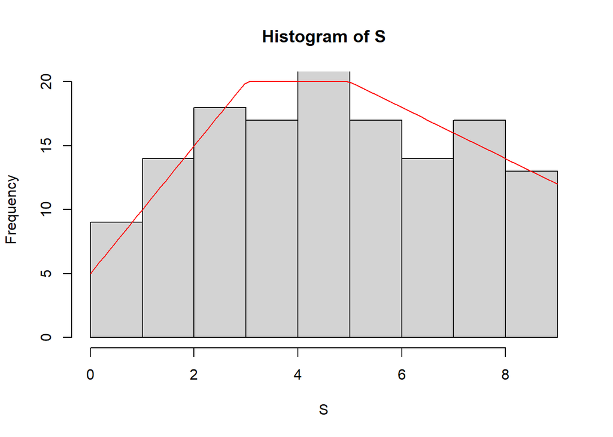

```r
#Esta funcion hace el calculo con k intervalos como parametro para la funcion
#lambda(s)
poisson<-function(Tmax,k,lambda) {
  #Se crea la secuencia de intervalos
  tj=seq(0,Tmax,by=Tmax/(k+1))
  li<-vector()
  #Se calcula lambda maximo para cada intervalo
  for (i in 1:(k+1)){
    li[i]=optimize(lambda,c(tj[i],tj[i+1]),maximum=TRUE)$objective
  }
  #Se ajusta tj para que solo tenga los valores maximos de cada intervalo
  tj=seq(0,Tmax,by=Tmax/(k+1))[2:(k+2)]
  #Se inicializan variables
  S<-vector();t<-0;J<-1;I<-0;flag=1;a<-1
      for (i in 1:1000) {
                            #Se realiza po primera vez el calculo de x como
                            #variable exponencial
                            if(flag==1){u1<-runif(1);   X<-((-1/li[J])*log(u1))}
                            while(t+X<=tj[J]){
                              t=t+X; u2<-runif(1)
                              if(u2<=(lambda(t)/li[J])) {I<-I+1;S[I]<-t}
                              #Recalculo de la variable exponencial
                              u1<-runif(1);   X<-((-1/li[J])*log(u1));a<-a+1
                            }

                              #Si se llega al ultimo intervalo, se sale
                              if(J==k+1){break}
                              #Se pasa al siguiente intervalo
                              X=(X-tj[J]+t)*li[J]/li[J+1];t=tj[J];J=J+1
                              flag=0




      }
    print("S")
    print(S)
    print("tasa de aceptación")
    print(length(S)/a)
    print("número medio de realizaciones")
    print(a/length(S))
    hist(S, breaks=9,ylim=c(0,20))
    curve(lambda(x),xlim=c(0,9),ylim=c(0,20),ylab="lambda(x)",col="red",add=TRUE)
  }

poisson(9,9,lambda)
```

Al comparar la implementación realizada en clase on la realizada en este notebook para el proceso de Poisson no homogéneo, se puede observar que la tasa de aceptación incrementa considerablemente en esta última; esto es debido a que, al generar subintervalos, los lambda(t) van a estar más cercanos al lambda máximo de cada uno de ellos, de tal modo que permite disminuir la cantidad de eventos rechazados.